# AE 06: Tidying Stat Sci

Suggested answers

**Important**

These are suggested answers. This document should be used as reference only, it’s not designed to be an exhaustive key.

## Goal

Our ultimate goal in this application exercise is to make the following data visualization.

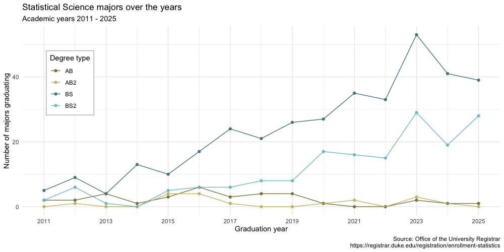

## Data

The data come from the [Office of the University Registrar](https://registrar.duke.edu/registration/enrollment-statistics). They make the data available as a table that you can download as a PDF, but I’ve put the data exported in a CSV file for you. Let’s load that in.

```r
library(tidyverse)

statsci <- read_csv("data/statsci_clean.csv")
```

And let’s take a look at the data.

```r
statsci
```

```
# A tibble: 4 × 16
  degree_type `2011` `2012` `2013` `2014` `2015` `2016` `2017` `2018` `2019`
  <chr>        <dbl>  <dbl>  <dbl>  <dbl>  <dbl>  <dbl>  <dbl>  <dbl>  <dbl>
1 AB2              0      1      0      0      4      4      1      0      0
2 AB               2      2      4      1      3      6      3      4      4
3 BS2              2      6      1      0      5      6      6      8      8
4 BS               5      9      4     13     10     17     24     21     26
# ℹ 6 more variables: `2020` <dbl>, `2021` <dbl>, `2022` <dbl>, `2023` <dbl>,
#   `2024` <dbl>, `2025` <dbl>
```

## Pivoting

- **Demo:** Pivot the `statsci` data frame *longer* such that:
  - Each row represents a degree type / year combination
  - `year` and `n`umber of graduates for that year are columns in the data frame
  - The resulting `year` column is numeric

```r
statsci |>
  pivot_longer(
    cols = -degree_type,
    names_to = "year",
    values_to = "n",
    names_transform = as.numeric
  )
```

```
# A tibble: 60 × 3
   degree_type  year     n
   <chr>       <dbl> <dbl>
 1 AB2          2011     0
 2 AB2          2012     1
 3 AB2          2013     0
 4 AB2          2014     0
 5 AB2          2015     4
 6 AB2          2016     4
 7 AB2          2017     1
 8 AB2          2018     0
 9 AB2          2019     0
10 AB2          2020     1
# ℹ 50 more rows
```

- **Your Turn:** Now, repeat your code from above, but this time **save the result** to a **new** dataframe.

```r
statsci_longer <- statsci |>
  pivot_longer(
    cols = -degree_type,
    names_to = "year",
    values_to = "n",
    names_transform = as.numeric
  )
```

## Plotting

- **Your turn:** Now we will start making our plot, but let’s not get too fancy right away. Create the following plot, which will serve as the “first draft” on the way to our goal. Which data frame should you use in your plot?

[figure not shown]

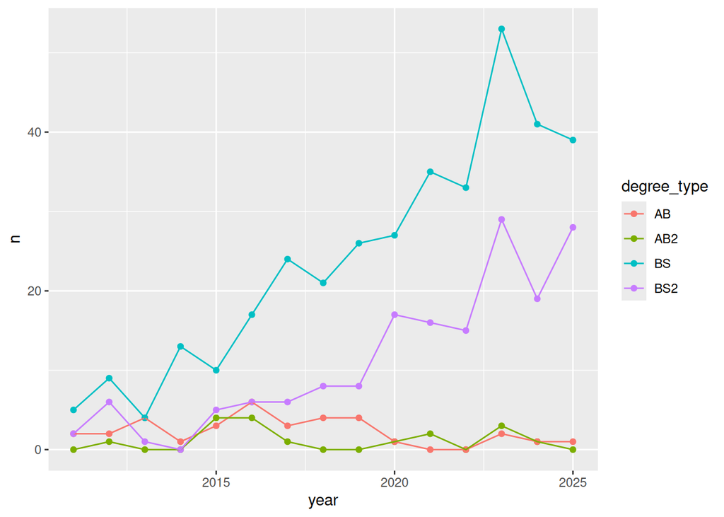

```r
ggplot(statsci_longer, aes(x = year, y = n, color = degree_type)) +
  geom_point() +
  geom_line()
```

- **Question**: Why was the pivot necessary in order to create this plot?

Our original dataframe had each year as it’s own column; we needed year to be one column where each obs. in our df represents a degree type - year combo.

- **Question:** What aspects of the plot need to be updated to go from the draft you created above to the goal plot at the beginning of this application exercise?

Theme, color scale, legend formatting, labels, scale of x-axis

- **Demo:** Update x-axis scale such that the years displayed go from 2011 to 2025 in increments of 2 years. Do this by adding on to your pipeline from earlier.

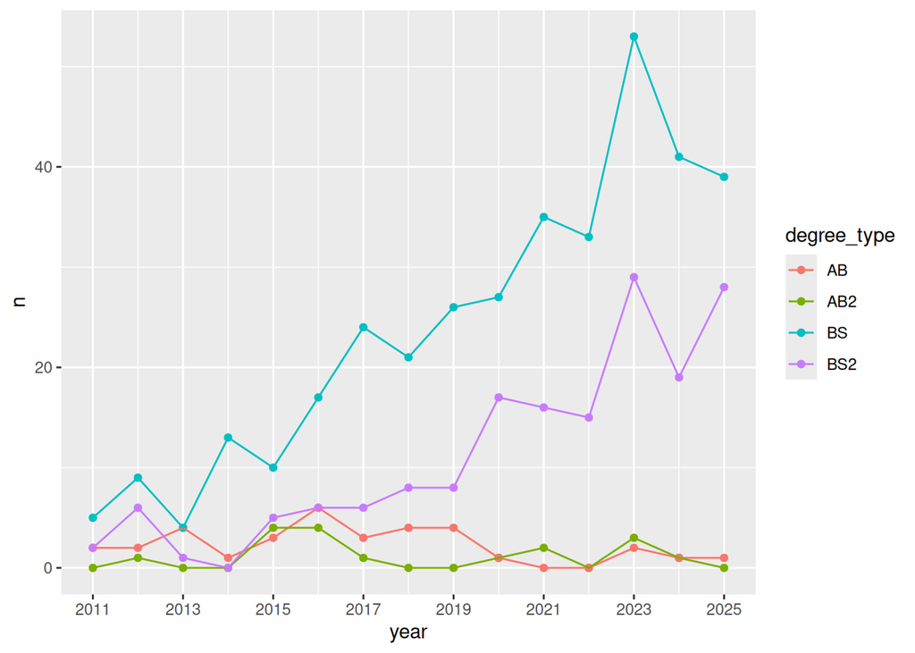

```r
ggplot(statsci_longer, aes(x = year, y = n, color = degree_type)) +
  geom_point() +
  geom_line() +
  scale_x_continuous(breaks = seq(2011, 2025, 2))
```

- **Demo:** Update line colors using the following level / color assignments. Once again, do this by adding on to your pipeline from earlier.
  - “BS” = “cadetblue4”
  - “BS2” = “cadetblue3”
  - “AB” = “lightgoldenrod4”
  - “AB2” = “lightgoldenrod3”

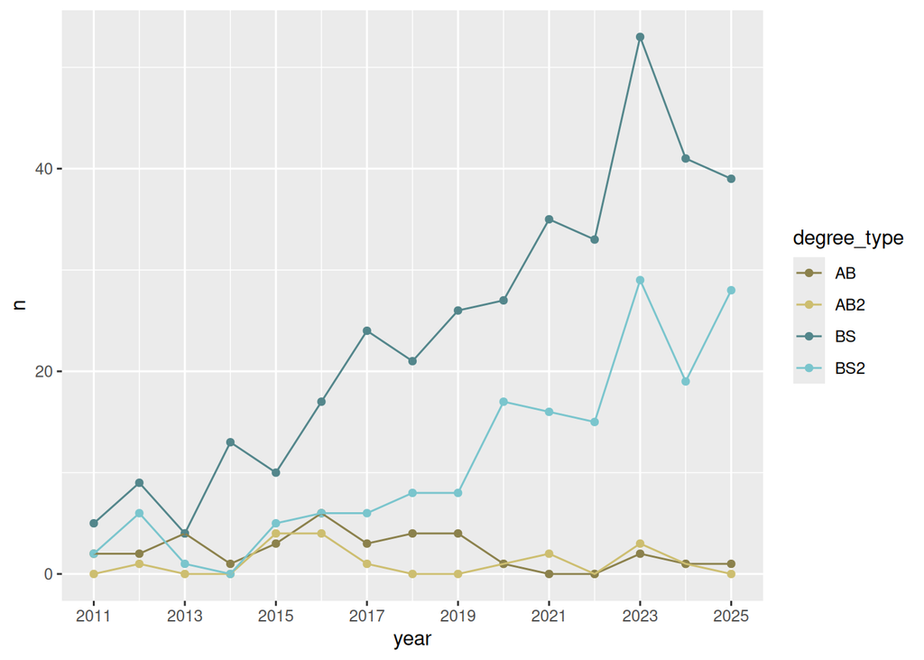

```r
ggplot(statsci_longer, aes(x = year, y = n, color = degree_type)) +
  geom_point() +
  geom_line() +
  scale_x_continuous(breaks = seq(2011, 2025, 2)) +
  scale_color_manual(
    values = c(
      "BS" = "cadetblue4",
      "BS2" = "cadetblue3",
      "AB" = "lightgoldenrod4",
      "AB2" = "lightgoldenrod3"
    )
  )
```

- **Your turn:** Update the plot labels (`title`, `subtitle`, `x`, `y`, and `caption`) and use `theme_minimal()`. Once again, do this by adding on to your pipeline from earlier.

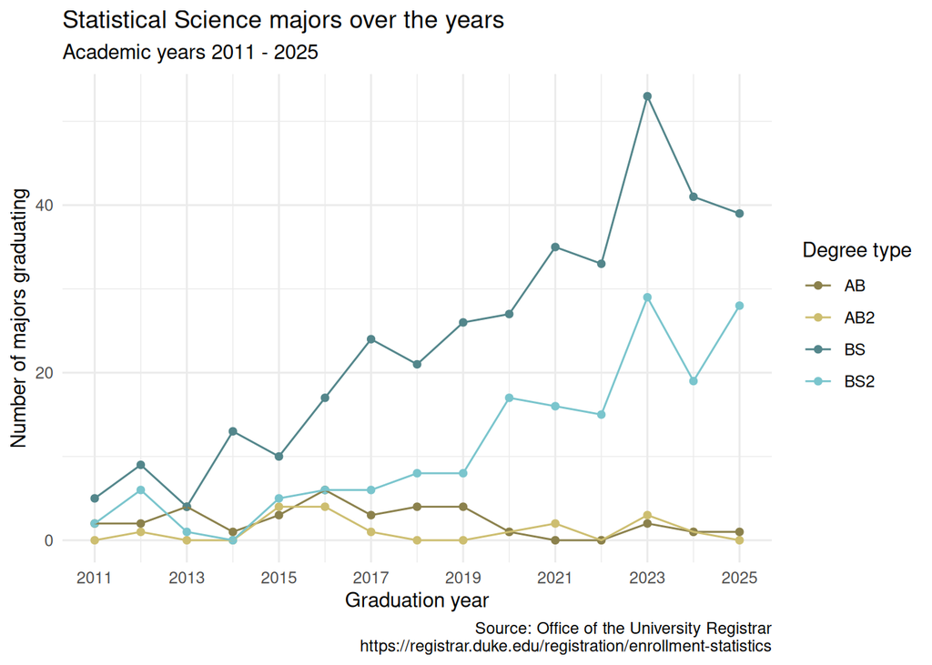

```r
ggplot(statsci_longer, aes(x = year, y = n, color = degree_type)) +
  geom_point() +
  geom_line() +
  scale_x_continuous(breaks = seq(2011, 2025, 2)) +
  scale_color_manual(
    values = c(
      "BS" = "cadetblue4",
      "BS2" = "cadetblue3",
      "AB" = "lightgoldenrod4",
      "AB2" = "lightgoldenrod3"
    )
  ) +
  labs(x = "Graduation year",
       y = "Number of majors graduating",
       title = "Statistical Science majors over the years",
       subtitle = "Academic years 2011 - 2025",
       color = "Degree type",
       caption  = "Source: Office of the University Registrar\nhttps://registrar.duke.edu/registration/enrollment-statistics") +
  theme_minimal()
```

- **Demo:** Adding to your pipeline you’ve developed so far, move the legend into the plot, make its background white, and its border gray.

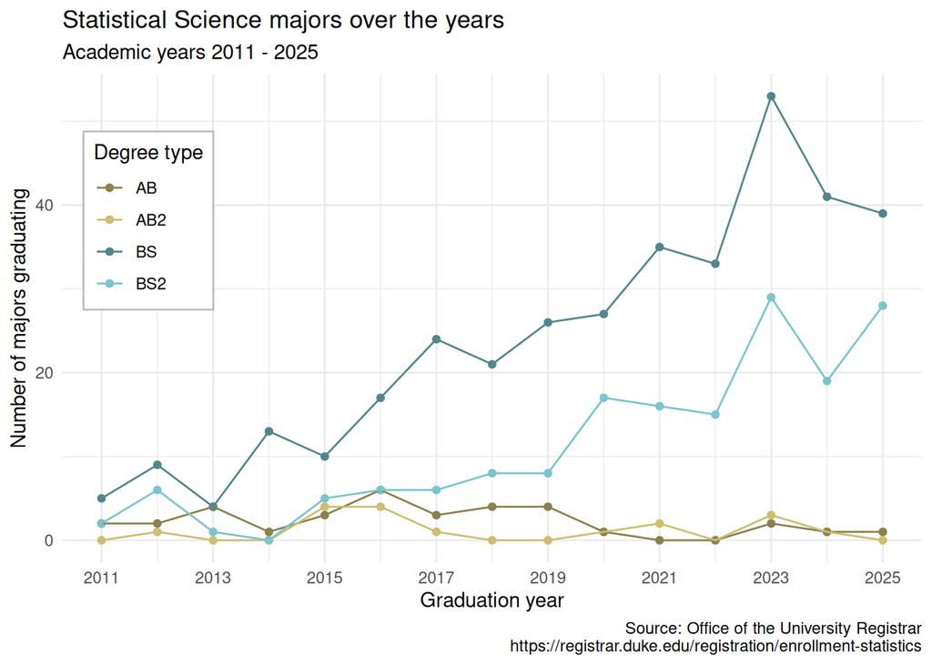

```r
ggplot(statsci_longer, aes(x = year, y = n, color = degree_type)) +
  geom_point() +
  geom_line() +
  scale_x_continuous(breaks = seq(2011, 2025, 2)) +
  scale_color_manual(
    values = c(
      "BS" = "cadetblue4",
      "BS2" = "cadetblue3",
      "AB" = "lightgoldenrod4",
      "AB2" = "lightgoldenrod3"
    )
  ) +
  labs(x = "Graduation year",
       y = "Number of majors graduating",
       title = "Statistical Science majors over the years",
       subtitle = "Academic years 2011 - 2025",
       color = "Degree type",
       caption  = "Source: Office of the University Registrar\nhttps://registrar.duke.edu/registration/enrollment-statistics") +
  theme_minimal() +
  theme(legend.position = "inside",
        legend.position.inside = c(.1, .7),
        legend.background = element_rect(fill = "white", color = "grey"))
```

- **Demo:** Finally, set `fig-width: 10` and `fig-height: 5` for your plot in the chunk options.

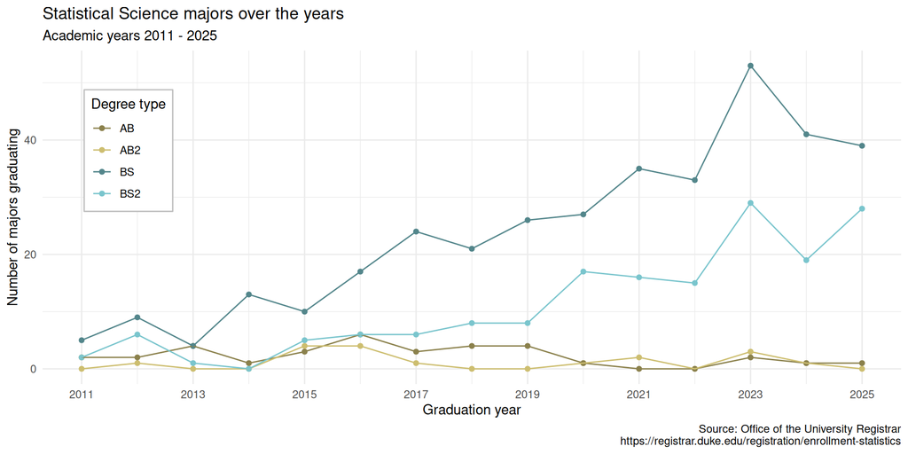

```r
ggplot(statsci_longer, aes(x = year, y = n, color = degree_type)) +
  geom_point() +
  geom_line() +
  scale_x_continuous(breaks = seq(2011, 2025, 2)) +
  scale_color_manual(
    values = c(
      "BS" = "cadetblue4",
      "BS2" = "cadetblue3",
      "AB" = "lightgoldenrod4",
      "AB2" = "lightgoldenrod3"
    )
  ) +
  labs(x = "Graduation year",
       y = "Number of majors graduating",
       title = "Statistical Science majors over the years",
       subtitle = "Academic years 2011 - 2025",
       color = "Degree type",
       caption  = "Source: Office of the University Registrar\nhttps://registrar.duke.edu/registration/enrollment-statistics") +
  theme_minimal() +
  theme(legend.position = "inside",
        legend.position.inside = c(.1, .7),
        legend.background = element_rect(fill = "white", color = "grey"))
```

## Let’s now pivot wider!

- **Demo:** Just like you can pivot longer, you can pivot wider. Let’s convert our longer data frame back into the wider one in a single pipeline.

```r
statsci_wide <- statsci_longer |>
  pivot_wider(
    names_from = year,
    values_from = n
  )

statsci_wide
```

```
# A tibble: 4 × 16
  degree_type `2011` `2012` `2013` `2014` `2015` `2016` `2017` `2018` `2019`
  <chr>        <dbl>  <dbl>  <dbl>  <dbl>  <dbl>  <dbl>  <dbl>  <dbl>  <dbl>
1 AB2              0      1      0      0      4      4      1      0      0
2 AB               2      2      4      1      3      6      3      4      4
3 BS2              2      6      1      0      5      6      6      8      8
4 BS               5      9      4     13     10     17     24     21     26
# ℹ 6 more variables: `2020` <dbl>, `2021` <dbl>, `2022` <dbl>, `2023` <dbl>,
#   `2024` <dbl>, `2025` <dbl>
```